# 2024 RA STAT3 Manuscript Analysis

### ESR T Test by Mutation

> Notes: Normality not met, log-transformed with small constant and ran t test, checked with wilcox test on raw data, also not significant

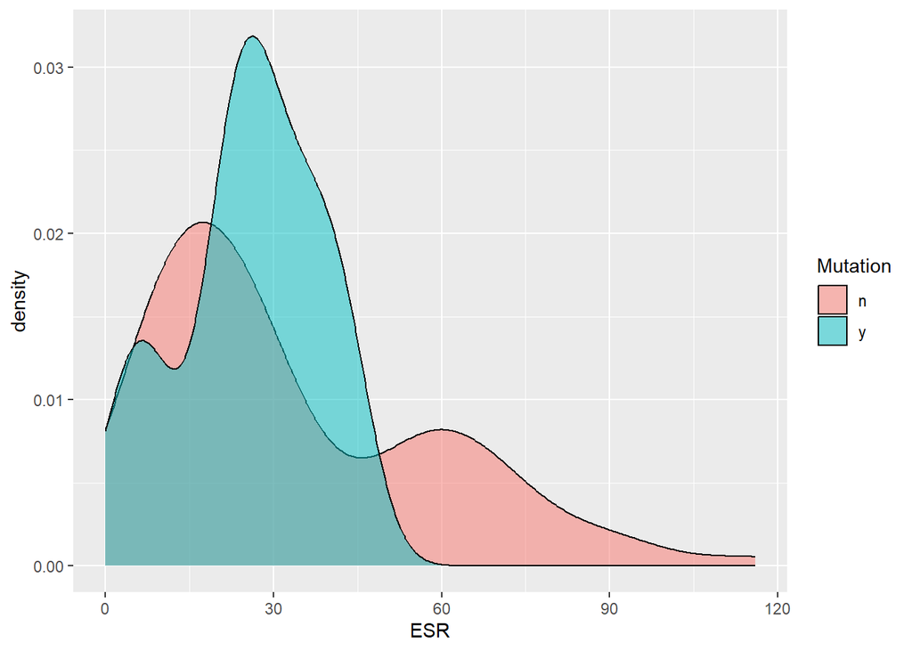

```r
RA %>%
  ggplot(aes(ESR, fill = Mutation))+geom_density(alpha = 0.5)
```

```r
#looks like a log transform would help, check for zeros
RA %>%
  arrange(ESR) %>%
  select(Mutation, ESR)
```

```
## # A tibble: 98 × 2
##    Mutation   ESR
##    <chr>    <dbl>
##  1 n            0
##  2 y            3
##  3 n            5
##  4 n            5
##  5 y            6
##  6 n            7
##  7 n            7
##  8 n            7
##  9 n            8
## 10 n            9
## # ℹ 88 more rows
```

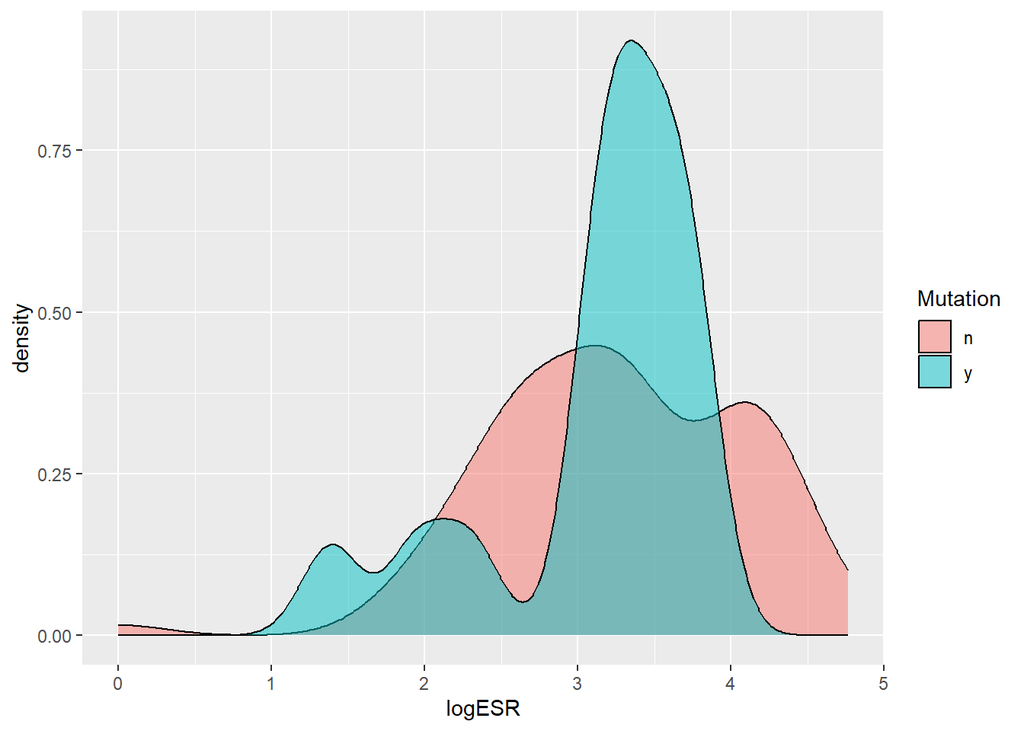

```r
#log transform and take care of zeros
RA <- RA %>%
  mutate(logESR = log(ESR + 1))

#data does have zeros, so need to do additional modification before log transform
RA %>%
  ggplot(aes(logESR, fill = Mutation))+geom_density(alpha = 0.5)
```

```r
t.test(logESR~Mutation, data = RA)
```

```
##
##  Welch Two Sample t-test
##
## data:  logESR by Mutation
## t = 0.66539, df = 21.685, p-value = 0.5128
## alternative hypothesis: true difference in means between group n and group y is not equal to 0
## 95 percent confidence interval:
##  -0.2854894  0.5548948
## sample estimates:
## mean in group n mean in group y
##        3.251105        3.116402
```

```r
wilcox.test(ESR~Mutation, data = RA)
```

```
##
##  Wilcoxon rank sum test with continuity correction
##
## data:  ESR by Mutation
## W = 650, p-value = 0.7306
## alternative hypothesis: true location shift is not equal to 0
```

```r
t.test(logESR~lowvafmut, data = RA)
```

```
##
##  Welch Two Sample t-test
##
## data:  logESR by lowvafmut
## t = 0.67787, df = 94.884, p-value = 0.4995
## alternative hypothesis: true difference in means between group n and group y is not equal to 0
## 95 percent confidence interval:
##  -0.2123401  0.4325286
## sample estimates:
## mean in group n mean in group y
##        3.288159        3.178065
```

```r
t.test(logESR~ymut, data = RA)
```

```
##
##  Welch Two Sample t-test
##
## data:  logESR by ymut
## t = -0.032517, df = 73.312, p-value = 0.9741
## alternative hypothesis: true difference in means between group n and group y is not equal to 0
## 95 percent confidence interval:
##  -0.3486077  0.3374140
## sample estimates:
## mean in group n mean in group y
##        3.227967        3.233563
```

```r
t.test(logESR~dmut, data = RA)
```

```
##
##  Welch Two Sample t-test
##
## data:  logESR by dmut
## t = 0.088316, df = 56.716, p-value = 0.9299
## alternative hypothesis: true difference in means between group n and group y is not equal to 0
## 95 percent confidence interval:
##  -0.3096410  0.3382104
## sample estimates:
## mean in group n mean in group y
##        3.233956        3.219671
```

```r
#checking if tidy works on wilcox
#resultswcx <- tidy(wilcox.test(ESR~Mutation, data = RA, var.equal = TRUE)) %>%
  #mutate(var = "ESR") %>%
  #rbind(resultswcx)

#turning this into a dataset

resultst <- tidy(t.test(logESR~Mutation, data = RA, var.equal = TRUE)) %>%
  mutate(var = "ESR") %>%
  rbind(resultst)

resultstlow <- tidy(t.test(logESR~lowvafmut, data = RA, var.equal = TRUE)) %>%
  mutate(var = "ESR") %>%
  rbind(resultstlow)
resultsty <- tidy(t.test(logESR~ymut, data = RA, var.equal = TRUE)) %>%
  mutate(var = "ESR") %>%
  rbind(resultsty)
resultstd <- tidy(t.test(logESR~dmut, data = RA, var.equal = TRUE)) %>%
  mutate(var = "ESR") %>%
  rbind(resultstd)

#clears table in case of error
#resultst <- data.frame()
```

### wbc T Test by Mutation

> notes: ran unequal variance t test on log data, not significant

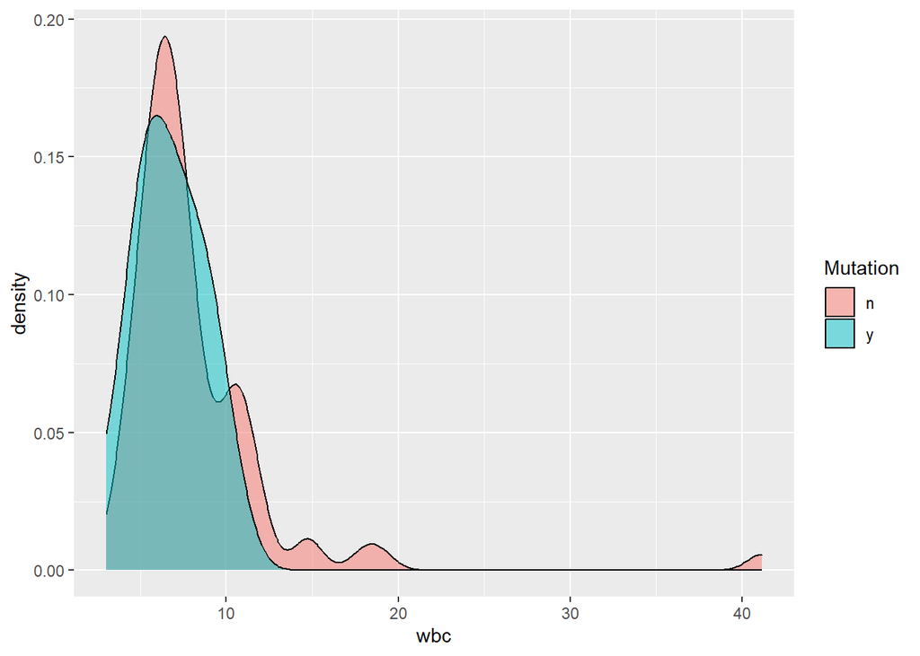

```r
RA %>%
  ggplot(aes(wbc, fill = Mutation))+geom_density(alpha = 0.5)
```

```r
#looks like a log transform would help, check for zeros
RA %>%
  arrange(wbc) %>%
  select(Mutation, wbc)
```

```
## # A tibble: 98 × 2
##    Mutation   wbc
##    <chr>    <dbl>
##  1 y         3.03
##  2 n         3.32
##  3 n         3.77
##  4 n         4.2
##  5 n         4.33
##  6 y         4.34
##  7 n         4.42
##  8 n         4.52
##  9 n         4.58
## 10 y         4.67
## # ℹ 88 more rows
```

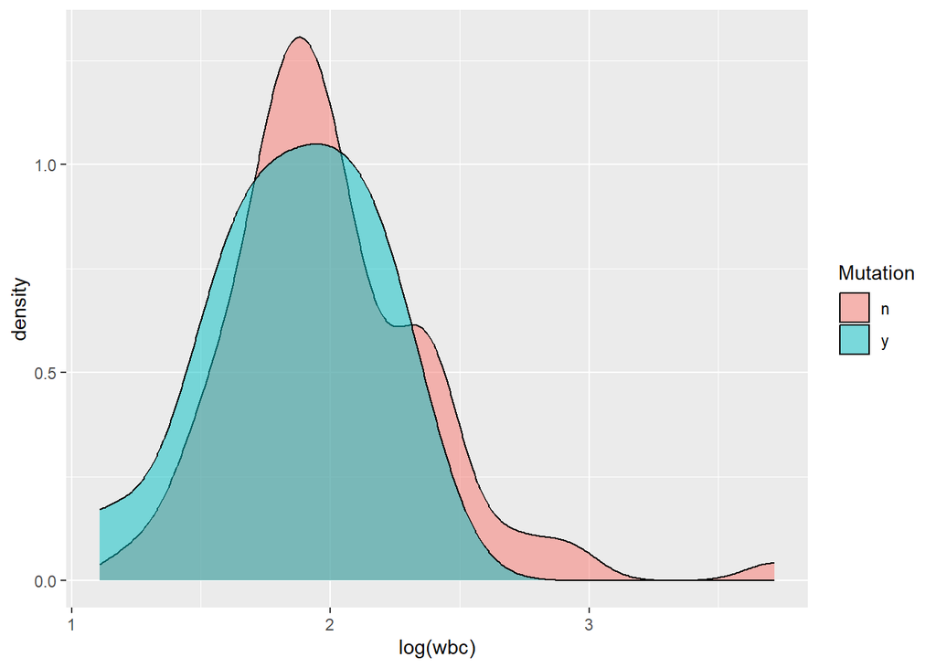

```r
#no zeros, so just take log
RA %>%
  ggplot(aes(log(wbc), fill = Mutation))+geom_density(alpha = 0.5)
```

Variance was not equal, did unequal variance t test on log data

```r
t.test(log(wbc)~Mutation, data = RA)
```

```
##
##  Welch Two Sample t-test
##
## data:  log(wbc) by Mutation
## t = 1.5432, df = 24.093, p-value = 0.1358
## alternative hypothesis: true difference in means between group n and group y is not equal to 0
## 95 percent confidence interval:
##  -0.04811251  0.33351248
## sample estimates:
## mean in group n mean in group y
##         1.99938         1.85668
```

```r
t.test(log(wbc)~lowvafmut, data = RA)
```

```
##
##  Welch Two Sample t-test
##
## data:  log(wbc) by lowvafmut
## t = -0.06831, df = 80.717, p-value = 0.9457
## alternative hypothesis: true difference in means between group n and group y is not equal to 0
## 95 percent confidence interval:
##  -0.1632549  0.1524177
## sample estimates:
## mean in group n mean in group y
##        1.973207        1.978625
```

```r
t.test(log(wbc)~ymut, data = RA)
```

```
##
##  Welch Two Sample t-test
##
## data:  log(wbc) by ymut
## t = 0.30214, df = 95.362, p-value = 0.7632
## alternative hypothesis: true difference in means between group n and group y is not equal to 0
## 95 percent confidence interval:
##  -0.1271161  0.1727574
## sample estimates:
## mean in group n mean in group y
##        1.985629        1.962809
```

```r
t.test(log(wbc)~dmut, data = RA)
```

```
##
##  Welch Two Sample t-test
##
## data:  log(wbc) by dmut
## t = 0.43496, df = 54.629, p-value = 0.6653
## alternative hypothesis: true difference in means between group n and group y is not equal to 0
## 95 percent confidence interval:
##  -0.1221234  0.1898165
## sample estimates:
## mean in group n mean in group y
##        1.984716        1.950870
```

```r
#turning this into a dataset

resultst <- tidy(t.test(log(wbc)~Mutation, data = RA, var.equal = TRUE)) %>%
  mutate(var = "WBC") %>%
  rbind(resultst)

resultstlow <- tidy(t.test(log(wbc)~lowvafmut, data = RA, var.equal = TRUE)) %>%
  mutate(var = "WBC") %>%
  rbind(resultstlow)
resultsty <- tidy(t.test(log(wbc)~ymut, data = RA, var.equal = TRUE)) %>%
  mutate(var = "WBC") %>%
  rbind(resultsty)
resultstd <- tidy(t.test(log(wbc)~dmut, data = RA, var.equal = TRUE)) %>%
  mutate(var = "WBC") %>%
  rbind(resultstd)
```

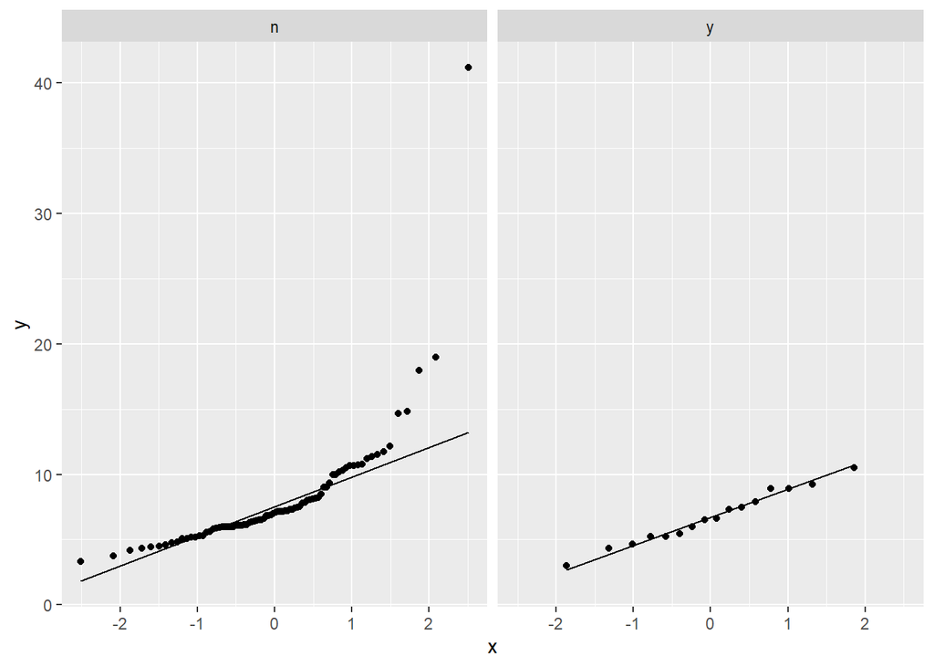

```r
RA %>%
  ggplot(aes(sample = wbc)) +
  geom_qq()+
  geom_qq_line()+
  facet_wrap(~Mutation)
```

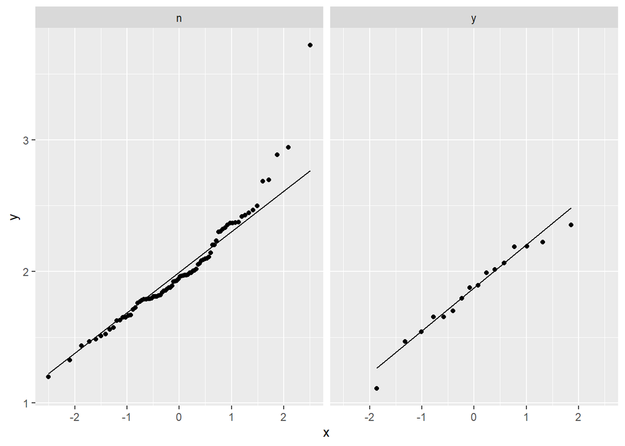

```r
RA %>%
  ggplot(aes(sample = log(wbc))) +
  geom_qq()+
  geom_qq_line()+
  facet_wrap(~Mutation)
```

### ALC T Test by Mutation >Notes: Data looks normal with unequal variance, used unequal variance t test, not significant

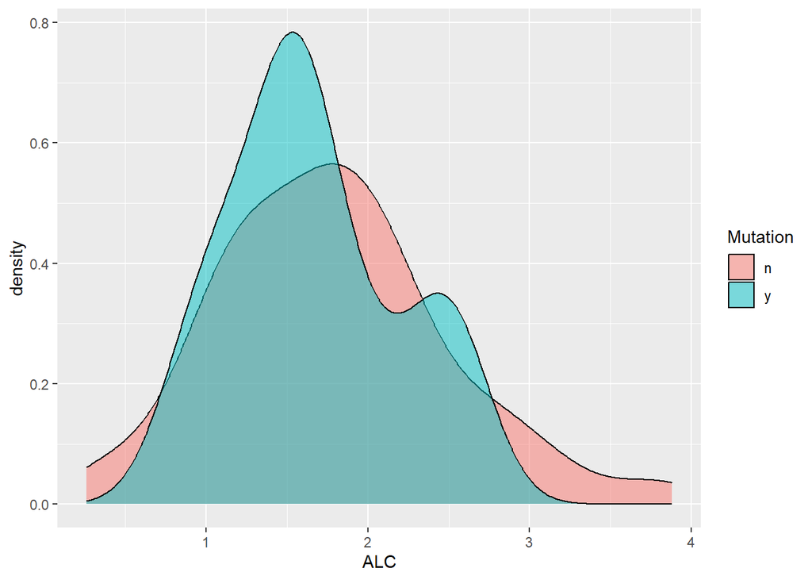

```r
RA %>%
  ggplot(aes(ALC, fill = Mutation))+geom_density(alpha = 0.5)
```

Run unequal variance t test with the data

```r
t.test(ALC~Mutation, data = RA)
```

```
##
##  Welch Two Sample t-test
##
## data:  ALC by Mutation
## t = 0.70416, df = 24.459, p-value = 0.488
## alternative hypothesis: true difference in means between group n and group y is not equal to 0
## 95 percent confidence interval:
##  -0.2144239  0.4368437
## sample estimates:
## mean in group n mean in group y
##        1.776543        1.665333
```

```r
t.test(ALC~lowvafmut, data = RA)
```

```
##
##  Welch Two Sample t-test
##
## data:  ALC by lowvafmut
## t = 0.094155, df = 91.967, p-value = 0.9252
## alternative hypothesis: true difference in means between group n and group y is not equal to 0
## 95 percent confidence interval:
##  -0.2669857  0.2935596
## sample estimates:
## mean in group n mean in group y
##        1.766087        1.752800
```

```r
t.test(ALC~ymut, data = RA)
```

```
##
##  Welch Two Sample t-test
##
## data:  ALC by ymut
## t = 0.096152, df = 87.123, p-value = 0.9236
## alternative hypothesis: true difference in means between group n and group y is not equal to 0
## 95 percent confidence interval:
##  -0.2669654  0.2941083
## sample estimates:
## mean in group n mean in group y
##        1.764821        1.751250
```

```r
t.test(ALC~dmut, data = RA)
```

```
##
##  Welch Two Sample t-test
##
## data:  ALC by dmut
## t = -0.0073433, df = 44.95, p-value = 0.9942
## alternative hypothesis: true difference in means between group n and group y is not equal to 0
## 95 percent confidence interval:
##  -0.3058736  0.3036514
## sample estimates:
## mean in group n mean in group y
##        1.758889        1.760000
```

```r
#turning this into a dataset

resultst <- tidy(t.test(ALC~Mutation, data = RA, var.equal = TRUE)) %>%
  mutate(var = "ALC") %>%
  rbind(resultst)

resultstlow <- tidy(t.test(ALC~lowvafmut, data = RA, var.equal = TRUE)) %>%
  mutate(var = "ALC") %>%
  rbind(resultstlow)
resultsty <- tidy(t.test(ALC~ymut, data = RA, var.equal = TRUE)) %>%
  mutate(var = "ALC") %>%
  rbind(resultsty)
resultstd <- tidy(t.test(ALC~dmut, data = RA, var.equal = TRUE)) %>%
  mutate(var = "ALC") %>%
  rbind(resultstd)

#wilcox.test(ALC~Mutation, data = RA)
```

Density plots are not the best option to assess normality, qqplots are better

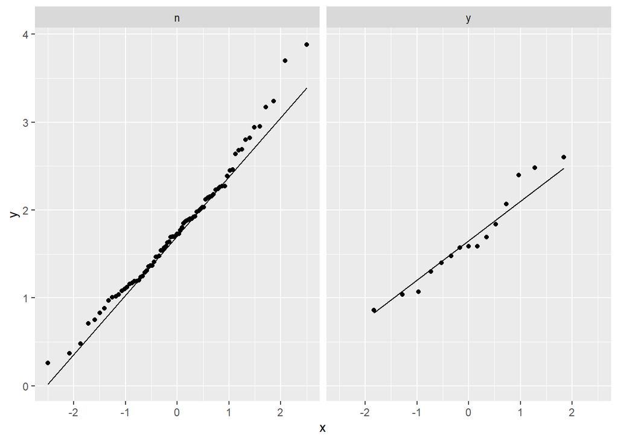

```r
RA %>%
  ggplot(aes(sample = ALC)) +
  geom_qq()+
  geom_qq_line()+
  facet_wrap(~Mutation)
```

### ANC T Test by Mutation by

> ran both equal variance t test on log data and wilcox on raw data, no significance

make a plot

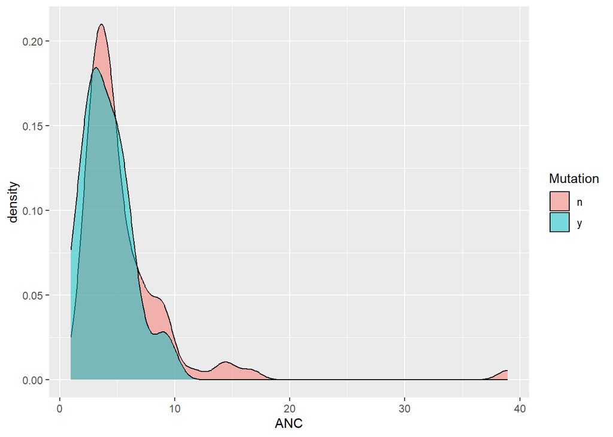

```r
RA %>%
  ggplot(aes(ANC, fill = Mutation))+geom_density(alpha = 0.5)
```

```r
#looks like a log transform would help
RA %>%
  arrange(ANC) %>%
  select(Mutation, ANC)
```

```
## # A tibble: 98 × 2
##    Mutation   ANC
##    <chr>    <dbl>
##  1 y         0.96
##  2 n         1.22
##  3 y         1.52
##  4 n         2.21
##  5 n         2.32
##  6 n         2.35
##  7 n         2.39
##  8 n         2.43
##  9 n         2.45
## 10 y         2.45
## # ℹ 88 more rows
```

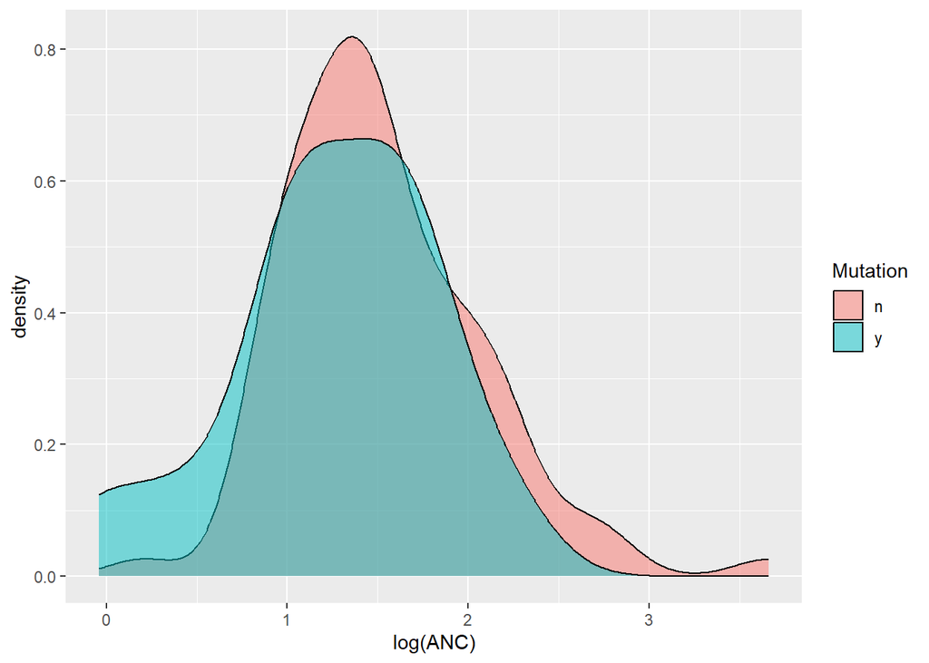

```r
#no zeros, so just take log
RA %>%
  ggplot(aes(log(ANC), fill = Mutation))+geom_density(alpha = 0.5)
```

Run equal variance t test with the log data or use raw data and run wilcox test

```r
t.test(log(ANC)~Mutation, data = RA, var.equal = TRUE)
```

```
##
##  Two Sample t-test
##
## data:  log(ANC) by Mutation
## t = 1.7232, df = 94, p-value = 0.08814
## alternative hypothesis: true difference in means between group n and group y is not equal to 0
## 95 percent confidence interval:
##  -0.04053444  0.57312910
## sample estimates:
## mean in group n mean in group y
##        1.528015        1.261717
```

```r
wilcox.test(ANC~Mutation, data = RA)
```

```
##
##  Wilcoxon rank sum test with continuity correction
##
## data:  ANC by Mutation
## W = 727, p-value = 0.2298
## alternative hypothesis: true location shift is not equal to 0
```

```r
t.test(log(ANC)~lowvafmut, data = RA, var.equal = TRUE)
```

```
##
##  Two Sample t-test
##
## data:  log(ANC) by lowvafmut
## t = -0.038122, df = 94, p-value = 0.9697
## alternative hypothesis: true difference in means between group n and group y is not equal to 0
## 95 percent confidence interval:
##  -0.2308524  0.2221546
## sample estimates:
## mean in group n mean in group y
##        1.484141        1.488490
```

```r
t.test(log(ANC)~ymut, data = RA, var.equal = TRUE)
```

```
##
##  Two Sample t-test
##
## data:  log(ANC) by ymut
## t = 0.37759, df = 94, p-value = 0.7066
## alternative hypothesis: true difference in means between group n and group y is not equal to 0
## 95 percent confidence interval:
##  -0.1857305  0.2729592
## sample estimates:
## mean in group n mean in group y
##        1.504578        1.460964
```

```r
t.test(log(ANC)~dmut, data = RA, var.equal = TRUE)
```

```
##
##  Two Sample t-test
##
## data:  log(ANC) by dmut
## t = 0.42201, df = 94, p-value = 0.674
## alternative hypothesis: true difference in means between group n and group y is not equal to 0
## 95 percent confidence interval:
##  -0.2055826  0.3165602
## sample estimates:
## mean in group n mean in group y
##        1.500278        1.444789
```

```r
#turning this into a dataset

resultst <- tidy(t.test(log(ANC)~Mutation, data = RA, var.equal = TRUE)) %>%
  mutate(var = "ANC") %>%
  rbind(resultst)

resultstlow <- tidy(t.test(log(ANC)~lowvafmut, data = RA, var.equal = TRUE)) %>%
  mutate(var = "ANC") %>%
  rbind(resultstlow)
resultsty <- tidy(t.test(log(ANC)~ymut, data = RA, var.equal = TRUE)) %>%
  mutate(var = "ANC") %>%
  rbind(resultsty)
resultstd <- tidy(t.test(log(ANC)~dmut, data = RA, var.equal = TRUE)) %>%
  mutate(var = "ANC") %>%
  rbind(resultstd)
```

T-test Assumption Flow chart: - Random Sampling – if not met, no basic statistics are appropriate - Independent Samples – if not met, paired t-test - Normality – if not met, Wilcoxon-Mann-Whitney U test - Equal variance – if not met, Welch’s t-test - If equal variance and normality are not met, choose which assumption is worse. Wilcox test assumes equal variance

Density plots are not the best option to assess normality, qqplots are better

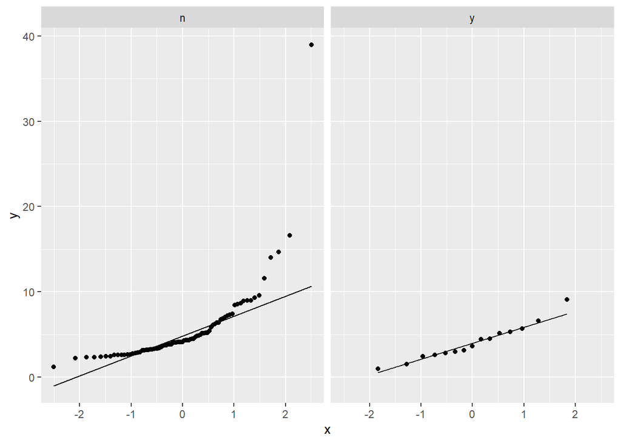

```r
RA %>%
  ggplot(aes(sample = ANC)) +
  geom_qq()+
  geom_qq_line()+
  facet_wrap(~Mutation)
```

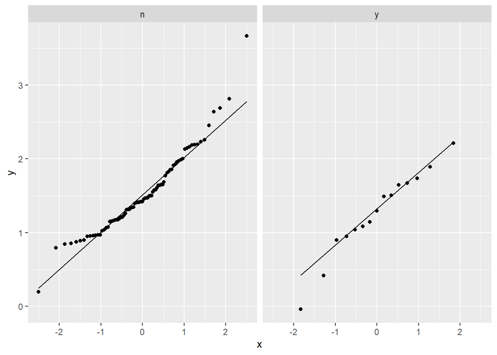

```r
RA %>%
  ggplot(aes(sample = log(ANC))) +
  geom_qq()+
  geom_qq_line()+
  facet_wrap(~Mutation)
```

### T Test of Mutation by txnum

> notes: ran unequal variance t test on log data with added constant, saw no significance

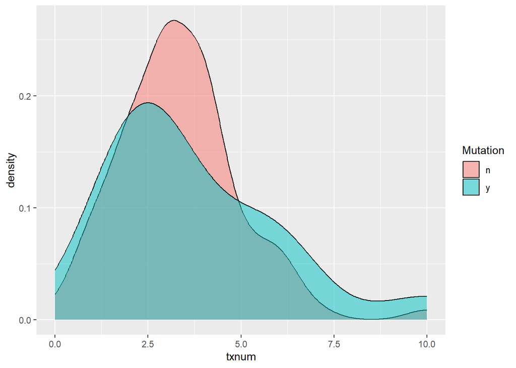

```r
RA %>%
  ggplot(aes(txnum, fill = Mutation))+geom_density(alpha = 0.5)
```

```r
#check for zeros to see if log transform is applicable
RA %>%
  arrange(txnum) %>%
  select(Mutation, txnum)
```

```
## # A tibble: 98 × 2
##    Mutation txnum
##    <chr>    <dbl>
##  1 n            0
##  2 n            1
##  3 n            1
##  4 n            1
##  5 n            1
##  6 n            1
##  7 n            1
##  8 n            1
##  9 n            1
## 10 y            1
## # ℹ 88 more rows
```

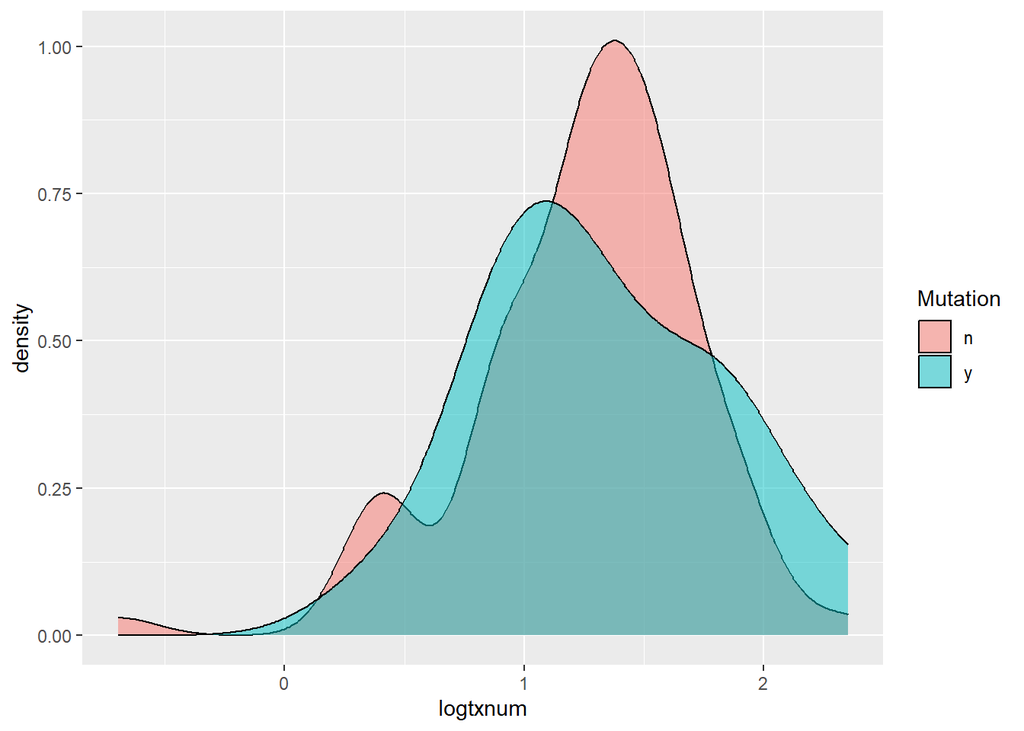

```r
#log transform and add value
RA <- RA %>%
  mutate(logtxnum = log(txnum + 0.5))

#data does have zeros, so need to do additional modification before log transform
RA %>%
  ggplot(aes(logtxnum, fill = Mutation))+geom_density(alpha = 0.5)
```

Run unequal variance t test with the log data

```r
t.test(logtxnum~Mutation, data = RA)
```

```
##
##  Welch Two Sample t-test
##
## data:  logtxnum by Mutation
## t = -0.53547, df = 20.378, p-value = 0.5981
## alternative hypothesis: true difference in means between group n and group y is not equal to 0
## 95 percent confidence interval:
##  -0.3575721  0.2113550
## sample estimates:
## mean in group n mean in group y
##        1.250240        1.323349
```

```r
t.test(logtxnum~lowvafmut, data = RA)
```

```
##
##  Welch Two Sample t-test
##
## data:  logtxnum by lowvafmut
## t = 1.4091, df = 93.772, p-value = 0.1621
## alternative hypothesis: true difference in means between group n and group y is not equal to 0
## 95 percent confidence interval:
##  -0.05408867  0.31851929
## sample estimates:
## mean in group n mean in group y
##        1.332331        1.200116
```

```r
t.test(logtxnum~ymut, data = RA)
```

```
##
##  Welch Two Sample t-test
##
## data:  logtxnum by ymut
## t = 0.89703, df = 76.837, p-value = 0.3725
## alternative hypothesis: true difference in means between group n and group y is not equal to 0
## 95 percent confidence interval:
##  -0.1092847  0.2884548
## sample estimates:
## mean in group n mean in group y
##        1.299656        1.210071
```

```r
t.test(logtxnum~dmut, data = RA)
```

```
##
##  Welch Two Sample t-test
##
## data:  logtxnum by dmut
## t = 0.18829, df = 43.874, p-value = 0.8515
## alternative hypothesis: true difference in means between group n and group y is not equal to 0
## 95 percent confidence interval:
##  -0.1958256  0.2361840
## sample estimates:
## mean in group n mean in group y
##        1.267324        1.247145
```

```r
#turning this into a dataset

resultst <- tidy(t.test(logtxnum~Mutation, data = RA, var.equal = TRUE)) %>%
  mutate(var = "Number of Treatments") %>%
  rbind(resultst)

resultstlow <- tidy(t.test(logtxnum~lowvafmut, data = RA, var.equal = TRUE)) %>%
  mutate(var = "Number of Treatments") %>%
  rbind(resultstlow)
resultsty <- tidy(t.test(logtxnum~ymut, data = RA, var.equal = TRUE)) %>%
  mutate(var = "Number of Treatments") %>%
  rbind(resultsty)
resultstd <- tidy(t.test(logtxnum~dmut, data = RA, var.equal = TRUE)) %>%
  mutate(var = "Number of Treatments") %>%
  rbind(resultstd)
```

### RF T Test by Mutation

> trying test with neg and pos removed, all others set to raw number

make a plot

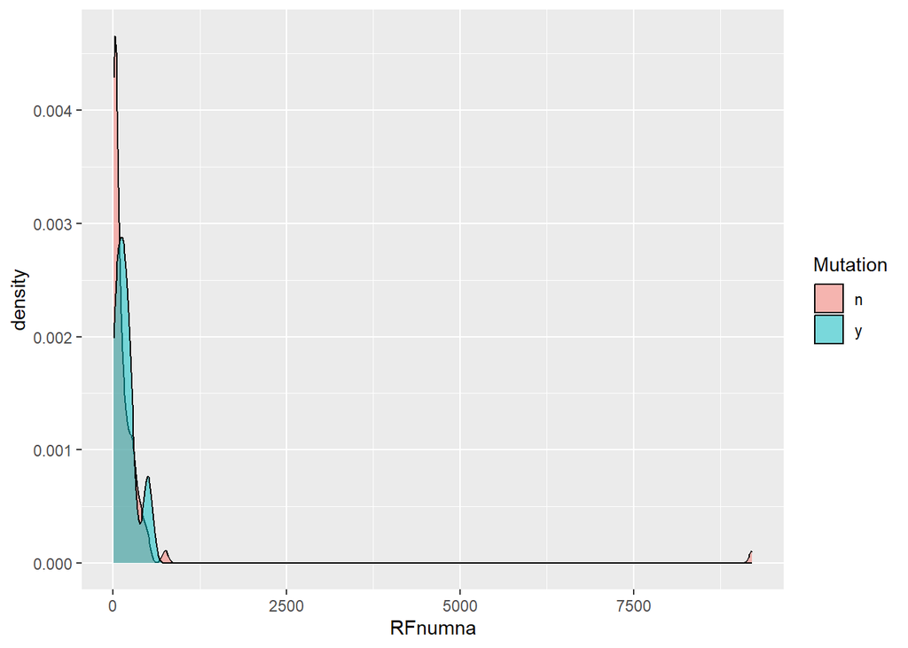

```r
RA %>%
  ggplot(aes(RFnumna, fill = Mutation))+geom_density(alpha = 0.5)
```

normality not fine, lots of 20s that could be something else with diff sensitivity, so best test is wilcoxon

```r
wilcox.test(RFnumna~Mutation, data = RA)
```

```
##
##  Wilcoxon rank sum test with continuity correction
##
## data:  RFnumna by Mutation
## W = 446.5, p-value = 0.1484
## alternative hypothesis: true location shift is not equal to 0
```

```r
RA %>%
  drop_na(Mutation, RFnumna) %>%
  group_by(Mutation) %>%
  summarise(n= n(),
            q10 = quantile(RFnumna, probs = .10),
            q20 = quantile(RFnumna, probs = .20),
            q30 = quantile(RFnumna, probs = .30),
            q40 = quantile(RFnumna, probs = .40),
            q50 = quantile(RFnumna, probs = .50),
            q60 = quantile(RFnumna, probs = .60),
            q70 = quantile(RFnumna, probs = .70),
            q80 = quantile(RFnumna, probs = .80),
            q90 = quantile(RFnumna, probs = .90)
            )
```

```
## # A tibble: 2 × 11
##   Mutation     n   q10   q20   q30   q40   q50   q60   q70   q80   q90
##   <chr>    <int> <dbl> <dbl> <dbl> <dbl> <dbl> <dbl> <dbl> <dbl> <dbl>
## 1 n           78  12.2  20    20    24.9  66.6  95.4  174.  244.  334.
## 2 y           15  23.6  49.2  77.4 128.  140.  172.   222   241.  403.
```

```r
wilcox.test(RFnumna~lowvafmut, data = RA)
```

```
##
##  Wilcoxon rank sum test with continuity correction
##
## data:  RFnumna by lowvafmut
## W = 1006.5, p-value = 0.5839
## alternative hypothesis: true location shift is not equal to 0
```

```r
wilcox.test(RFnumna~ymut, data = RA)
```

```
##
##  Wilcoxon rank sum test with continuity correction
##
## data:  RFnumna by ymut
## W = 863.5, p-value = 0.1401
## alternative hypothesis: true location shift is not equal to 0
```

```r
wilcox.test(RFnumna~dmut, data = RA)
```

```
##
##  Wilcoxon rank sum test with continuity correction
##
## data:  RFnumna by dmut
## W = 756.5, p-value = 0.532
## alternative hypothesis: true location shift is not equal to 0
```

Using wilcox with neg pos as missing not significant result, nos are lower than yeses

trying wilcox with neg pos filled in with medians, see cleaning

```r
wilcox.test(RFnum~Mutation, data = RA)
```

```
##
##  Wilcoxon rank sum test with continuity correction
##
## data:  RFnum by Mutation
## W = 484.5, p-value = 0.09901
## alternative hypothesis: true location shift is not equal to 0
```

```r
wilcox.test(RFnum~lowvafmut, data = RA)
```

```
##
##  Wilcoxon rank sum test with continuity correction
##
## data:  RFnum by lowvafmut
## W = 1089, p-value = 0.4467
## alternative hypothesis: true location shift is not equal to 0
```

```r
wilcox.test(RFnum~ymut, data = RA)
```

```
##
##  Wilcoxon rank sum test with continuity correction
##
## data:  RFnum by ymut
## W = 958, p-value = 0.129
## alternative hypothesis: true location shift is not equal to 0
```

```r
wilcox.test(RFnum~dmut, data = RA)
```

```
##
##  Wilcoxon rank sum test with continuity correction
##
## data:  RFnum by dmut
## W = 805, p-value = 0.3815
## alternative hypothesis: true location shift is not equal to 0
```

```r
RA %>%
  drop_na(Mutation, RFnum) %>%
  group_by(Mutation) %>%
  summarise(n= n(),
            q10 = quantile(RFnum, probs = .10),
            q20 = quantile(RFnum, probs = .20),
            q25 = quantile(RFnum, probs = .25),
            q30 = quantile(RFnum, probs = .30),
            q40 = quantile(RFnum, probs = .40),
            q50 = quantile(RFnum, probs = .50),
            q60 = quantile(RFnum, probs = .60),
            q70 = quantile(RFnum, probs = .70),
            q75 = quantile(RFnum, probs = .75),
            q80 = quantile(RFnum, probs = .80),
            q90 = quantile(RFnum, probs = .90)
            )
```

```
## # A tibble: 2 × 13
##   Mutation     n   q10   q20   q25   q30   q40   q50   q60   q70   q75   q80
##   <chr>    <int> <dbl> <dbl> <dbl> <dbl> <dbl> <dbl> <dbl> <dbl> <dbl> <dbl>
## 1 n           82  13    20    20    20    21.6  59.6  93.0  168.  177.   241
## 2 y           16  24.4  54.3  64.6  91.5 137   152.  171.   204   234.   235
## # ℹ 1 more variable: q90 <dbl>
```

```r
#making a table for wilcox p values
resultswcx <- tidy(wilcox.test(RFnum~Mutation, data = RA, var.equal = TRUE)) %>%
  mutate(var = "RF") %>%
  rbind(resultswcx)

resultswcxlow <- tidy(wilcox.test(RFnum~lowvafmut, data = RA, var.equal = TRUE)) %>%
  mutate(var = "RF") %>%
  rbind(resultswcxlow)
resultswcxy <- tidy(wilcox.test(RFnum~ymut, data = RA, var.equal = TRUE)) %>%
  mutate(var = "RF") %>%
  rbind(resultswcxy)
resultswcxd <- tidy(wilcox.test(RFnum~dmut, data = RA, var.equal = TRUE)) %>%
  mutate(var = "RF") %>%
  rbind(resultswcxd)
```

trying wilcox with neg pos filled in with conservative values 21 and 20

```r
wilcox.test(RFcons~Mutation, data = RA)
```

```
##
##  Wilcoxon rank sum test with continuity correction
##
## data:  RFcons by Mutation
## W = 502.5, p-value = 0.1399
## alternative hypothesis: true location shift is not equal to 0
```

### CCP T Test by Mutation

> trying test with neg and pos removed, all others set to raw number

make a plot

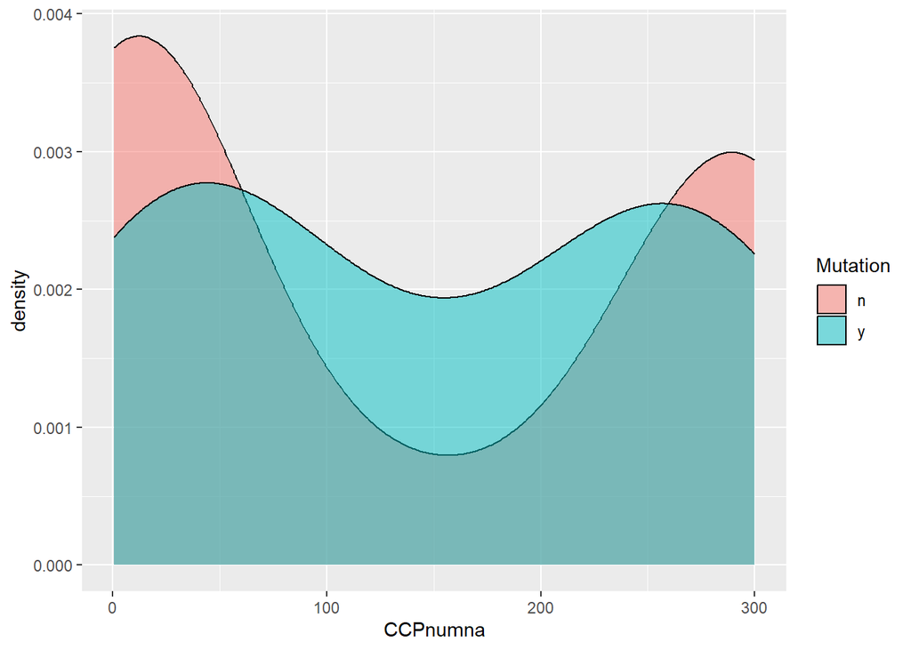

```r
RA %>%
  ggplot(aes(CCPnumna, fill = Mutation))+geom_density(alpha = 0.5)
```

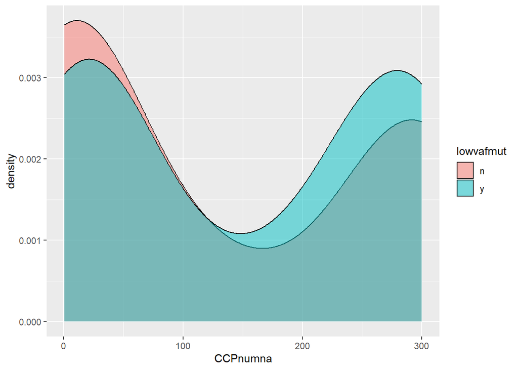

```r
RA %>%
  ggplot(aes(CCPnumna, fill = lowvafmut))+geom_density(alpha = 0.5)
```

normality not fine, lots mins and maxs that could be something else with diff sensitivity, so best test is wilcoxon

```r
wilcox.test(CCPnumna~Mutation, data = RA)
```

```
##
##  Wilcoxon rank sum test with continuity correction
##
## data:  CCPnumna by Mutation
## W = 403.5, p-value = 0.613
## alternative hypothesis: true location shift is not equal to 0
```

```r
wilcox.test(CCPnumna~lowvafmut, data = RA)
```

```
##
##  Wilcoxon rank sum test with continuity correction
##
## data:  CCPnumna by lowvafmut
## W = 809.5, p-value = 0.3157
## alternative hypothesis: true location shift is not equal to 0
```

```r
wilcox.test(CCPnumna~ymut, data = RA)
```

```
##
##  Wilcoxon rank sum test with continuity correction
##
## data:  CCPnumna by ymut
## W = 707, p-value = 0.1137
## alternative hypothesis: true location shift is not equal to 0
```

```r
wilcox.test(CCPnumna~dmut, data = RA)
```

```
##
##  Wilcoxon rank sum test with continuity correction
##
## data:  CCPnumna by dmut
## W = 660.5, p-value = 0.804
## alternative hypothesis: true location shift is not equal to 0
```

trying wilcox with neg pos filled in with medians, see cleaning

```r
wilcox.test(CCPnum~Mutation, data = RA)
```

```
##
##  Wilcoxon rank sum test with continuity correction
##
## data:  CCPnum by Mutation
## W = 434.5, p-value = 0.3387
## alternative hypothesis: true location shift is not equal to 0
```

```r
RA %>%
  drop_na(Mutation, CCPnum) %>%
  group_by(Mutation) %>%
  summarise(n= n(),
            q10 = quantile(CCPnum, probs = .10),
            q20 = quantile(CCPnum, probs = .20),
            q25 = quantile(CCPnum, probs = .25),
            q30 = quantile(CCPnum, probs = .30),
            q40 = quantile(CCPnum, probs = .40),
            q50 = quantile(CCPnum, probs = .50),
            q60 = quantile(CCPnum, probs = .60),
            q70 = quantile(CCPnum, probs = .70),
            q75 = quantile(CCPnum, probs = .75),
            q80 = quantile(CCPnum, probs = .80),
            q90 = quantile(CCPnum, probs = .90),
            )
```

```
## # A tibble: 2 × 13
##   Mutation     n   q10   q20   q25   q30   q40   q50   q60   q70   q75   q80
##   <chr>    <int> <dbl> <dbl> <dbl> <dbl> <dbl> <dbl> <dbl> <dbl> <dbl> <dbl>
## 1 n           80   0.5   0.5   0.5   1    15.6  38.5  162.  259.   300   300
## 2 y           13  21.3  25.4  30.4  60.0  93.5 174.   250   250    250   250
## # ℹ 1 more variable: q90 <dbl>
```

```r
wilcox.test(CCPnum~lowvafmut, data = RA)
```

```
##
##  Wilcoxon rank sum test with continuity correction
##
## data:  CCPnum by lowvafmut
## W = 986.5, p-value = 0.4676
## alternative hypothesis: true location shift is not equal to 0
```

```r
wilcox.test(CCPnum~ymut, data = RA)
```

```
##
##  Wilcoxon rank sum test with continuity correction
##
## data:  CCPnum by ymut
## W = 873, p-value = 0.1733
## alternative hypothesis: true location shift is not equal to 0
```

```r
wilcox.test(CCPnum~dmut, data = RA)
```

```
##
##  Wilcoxon rank sum test with continuity correction
##
## data:  CCPnum by dmut
## W = 754.5, p-value = 0.9926
## alternative hypothesis: true location shift is not equal to 0
```

```r
#turning it into a dataset

resultswcx <- tidy(wilcox.test(CCPnum~Mutation, data = RA, var.equal = TRUE)) %>%
  mutate(var = "Historical CCP") %>%
  rbind(resultswcx)

resultswcxlow <- tidy(wilcox.test(CCPnum~lowvafmut, data = RA, var.equal = TRUE)) %>%
  mutate(var = "Historical CCP") %>%
  rbind(resultswcxlow)
resultswcxy <- tidy(wilcox.test(CCPnum~ymut, data = RA, var.equal = TRUE)) %>%
  mutate(var = "Historical CCP") %>%
  rbind(resultswcxy)
resultswcxd <- tidy(wilcox.test(CCPnum~dmut, data = RA, var.equal = TRUE)) %>%
  mutate(var = "Historical CCP") %>%
  rbind(resultswcxd)
```

### Time Since Dx T Test by Mutation

> log transformed with small constant and ran T test, difference was significant

make a plot

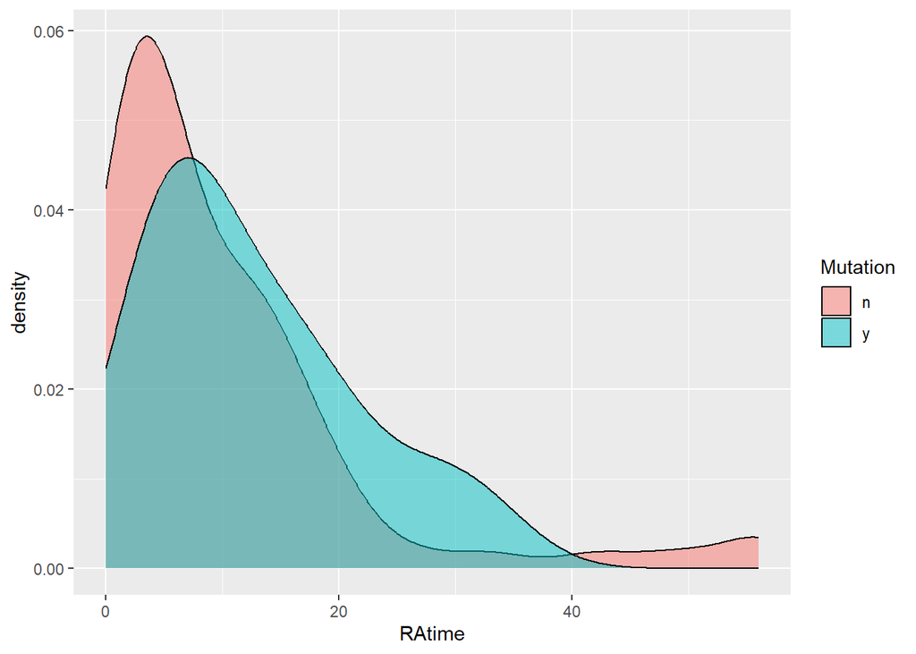

```r
RA %>%
  ggplot(aes(RAtime, fill = Mutation))+geom_density(alpha = 0.5)
```

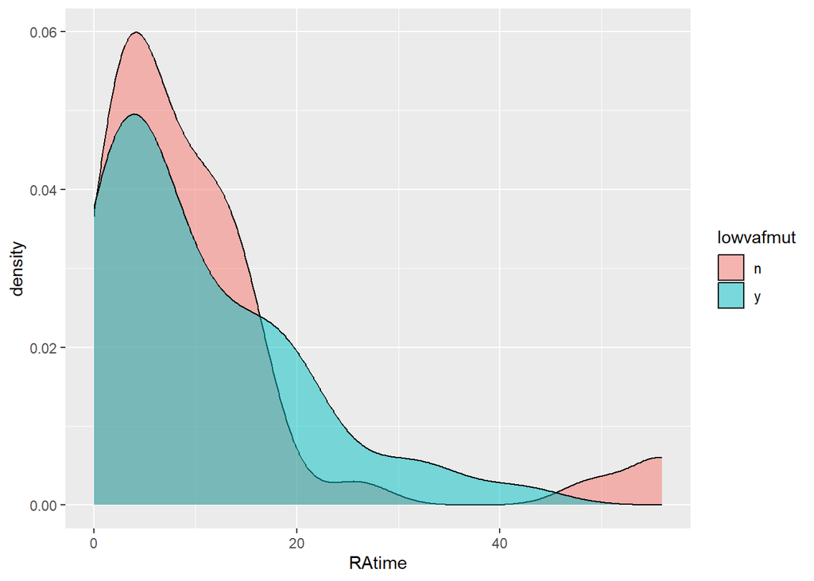

```r
RA %>%
  ggplot(aes(RAtime, fill = lowvafmut))+geom_density(alpha = 0.5)
```

check for zeros and log transform

```r
#check for zeros to see if log transform is applicable
RA %>%
  arrange(RAtime) %>%
  select(Mutation, RAtime)
```

```
## # A tibble: 98 × 2
##    Mutation RAtime
##    <chr>     <dbl>
##  1 n             0
##  2 n             0
##  3 n             0
##  4 n             0
##  5 n             1
##  6 n             1
##  7 n             1
##  8 n             1
##  9 n             1
## 10 n             1
## # ℹ 88 more rows
```

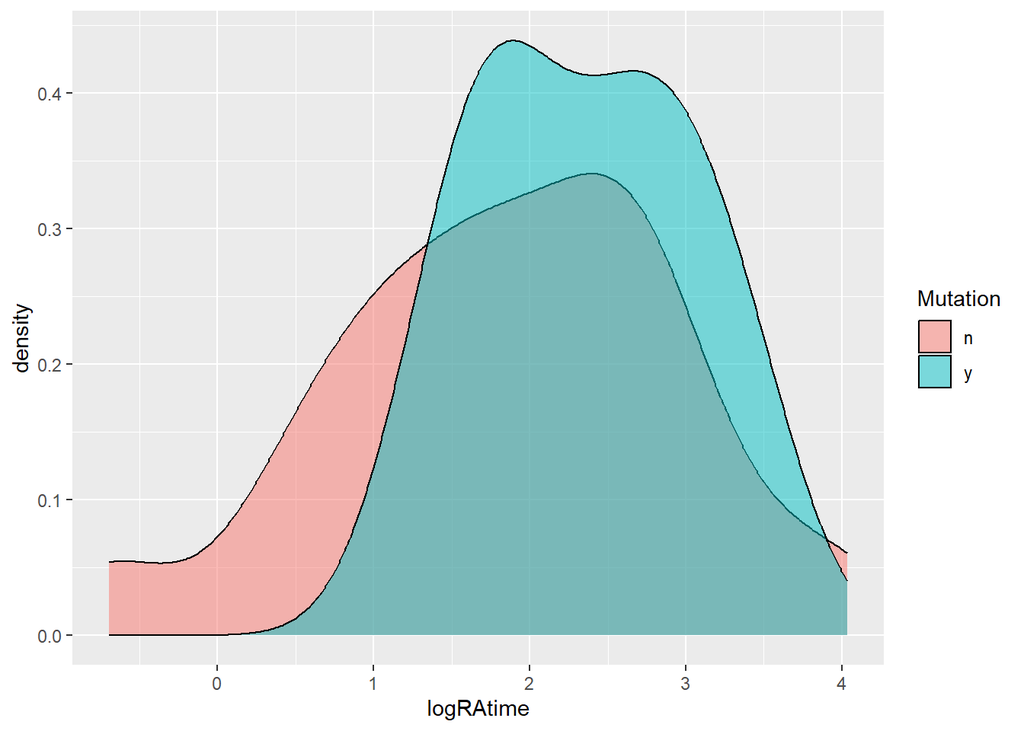

```r
#log transform and add value
RA <- RA %>%
  mutate(logRAtime = log(RAtime + 0.5))

#data does have zeros, so need to do additional modification before log transform
RA %>%
  ggplot(aes(logRAtime, fill = Mutation))+geom_density(alpha = 0.5)
```

Run unequal variance t test with the log data

```r
t.test(logRAtime~Mutation, data = RA)
```

```
##
##  Welch Two Sample t-test
##
## data:  logRAtime by Mutation
## t = -2.2215, df = 26.952, p-value = 0.03491
## alternative hypothesis: true difference in means between group n and group y is not equal to 0
## 95 percent confidence interval:
##  -0.96795546 -0.03838918
## sample estimates:
## mean in group n mean in group y
##        1.845853        2.349025
```

```r
t.test(logRAtime~lowvafmut, data = RA)
```

```
##
##  Welch Two Sample t-test
##
## data:  logRAtime by lowvafmut
## t = 0.4657, df = 83.77, p-value = 0.6426
## alternative hypothesis: true difference in means between group n and group y is not equal to 0
## 95 percent confidence interval:
##  -0.3455625  0.5568944
## sample estimates:
## mean in group n mean in group y
##        1.978736        1.873070
```

```r
t.test(logRAtime~ymut, data = RA)
```

```
##
##  Welch Two Sample t-test
##
## data:  logRAtime by ymut
## t = -0.19588, df = 67.878, p-value = 0.8453
## alternative hypothesis: true difference in means between group n and group y is not equal to 0
## 95 percent confidence interval:
##  -0.5201950  0.4272009
## sample estimates:
## mean in group n mean in group y
##        1.906881        1.953378
```

```r
t.test(logRAtime~dmut, data = RA)
```

```
##
##  Welch Two Sample t-test
##
## data:  logRAtime by dmut
## t = -0.87596, df = 31.49, p-value = 0.3877
## alternative hypothesis: true difference in means between group n and group y is not equal to 0
## 95 percent confidence interval:
##  -0.7792108  0.3107722
## sample estimates:
## mean in group n mean in group y
##        1.872671        2.106891
```

```r
#turning this into a dataset

resultst <- tidy(t.test(logRAtime~Mutation, data = RA)) %>%
  mutate(var = "Time Since Dx") %>%
  rbind(resultst)

resultstlow <- tidy(t.test(logRAtime~lowvafmut, data = RA)) %>%
  mutate(var = "Time Since Dx") %>%
  rbind(resultstlow)
resultsty <- tidy(t.test(logRAtime~ymut, data = RA)) %>%
  mutate(var = "Time Since Dx") %>%
  rbind(resultsty)
resultstd <- tidy(t.test(logRAtime~dmut, data = RA)) %>%
  mutate(var = "Time Since Dx") %>%
  rbind(resultstd)
```

# ANOVAs for quantitative data by mutation type (WT, D661Y, Y640F)

Variables are: “age”, “SJ”, “TJ”, “pt_global”, “pro_global”, “hopCCP”, “CRP”, “ESR”, “wbc”, “ALC”, “ANC”, “txnum”

warning: the age and sj must come first when making datasets for p values because all other vars have append, and if order is switched, the file will overwrite

look at count of mutation type

```r
RA %>% count(muttype)
```

```
## # A tibble: 4 × 2
##   muttype     n
##   <chr>   <int>
## 1 D661Y       6
## 2 WT         82
## 3 Y640F       8
## 4 <NA>        2
```

```r
RA %>% count(muttypelow)
```

```
## # A tibble: 4 × 2
##   muttypelow     n
##   <chr>      <int>
## 1 D661Y         11
## 2 WT            46
## 3 Y640F         27
## 4 <NA>          14
```

make RA object without muttype na

```r
RA3 <- RA %>% drop_na(muttype)

RA4 <- RA %>% drop_na(muttypelow)
```

### Age Anova

Make a box plot

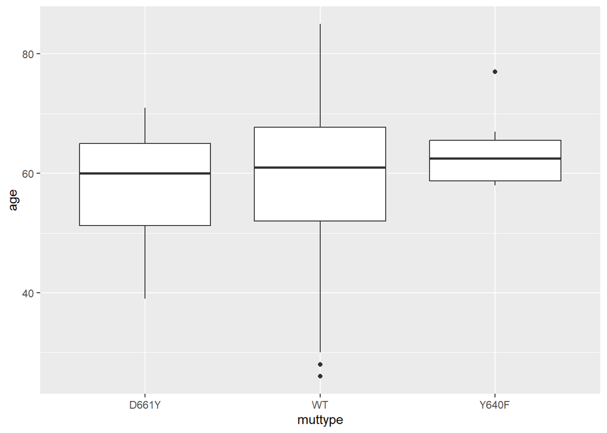

```r
RA3 %>% ggplot(aes(muttype, age))+geom_boxplot()
```

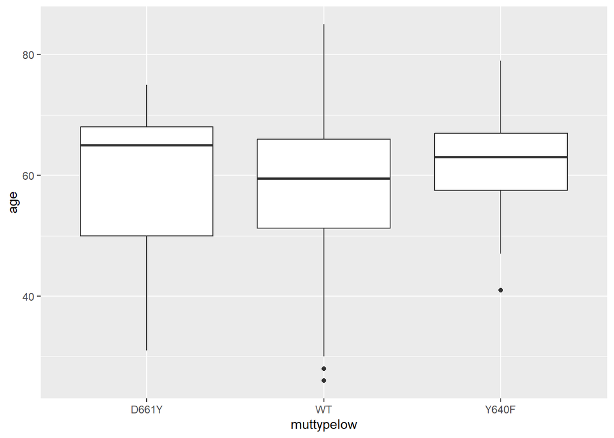

```r
RA4 %>% ggplot(aes(muttypelow, age))+geom_boxplot()
```

Run anova in order to test assumptions based on first plot, don’t have equal variance based on second plot, normality is met ignore the 4th plot

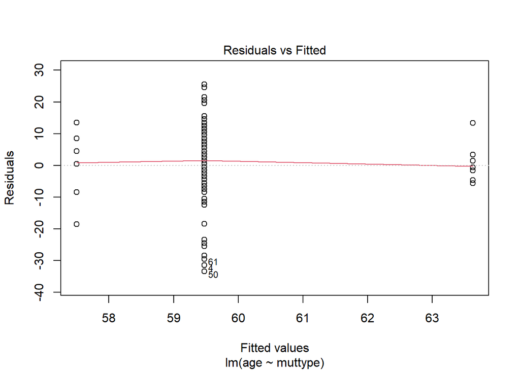

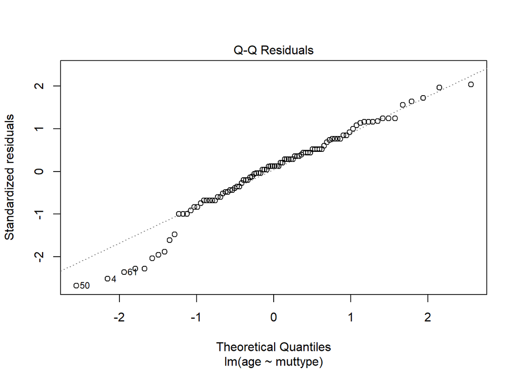

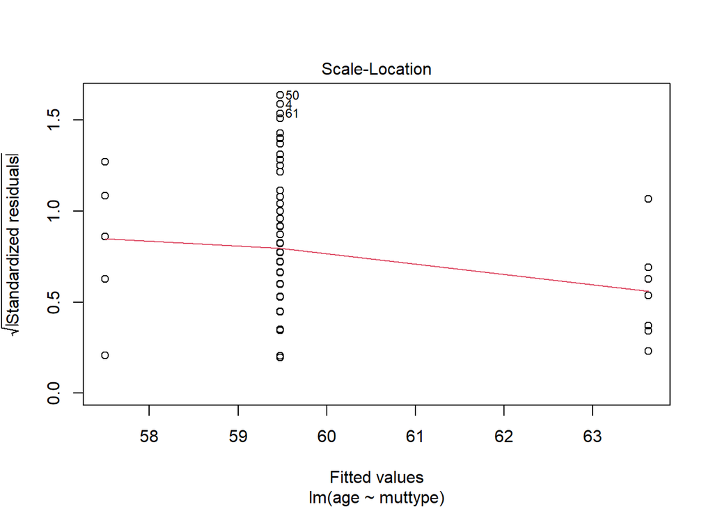

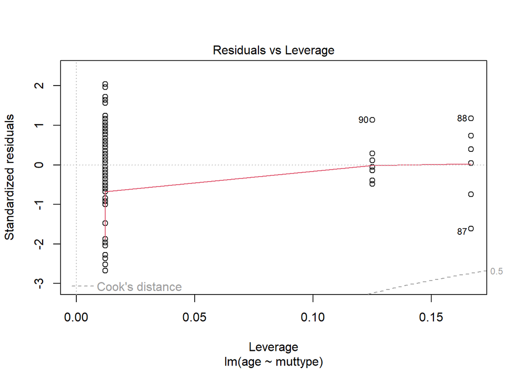

```r
mod<- lm(age~muttype, data = RA3)
plot(mod)
```

nonequal variance, so welch’s anova

```r
RA3 %>% welch_anova_test(age~muttype)
```

```
## # A tibble: 1 × 7
##   .y.       n statistic   DFn   DFd     p method
## * <chr> <int>     <dbl> <dbl> <dbl> <dbl> <chr>
## 1 age      96      1.34     2  10.5 0.303 Welch ANOVA
```

```r
RA4 %>% welch_anova_test(age~muttypelow)
```

```
## # A tibble: 1 × 7
##   .y.       n statistic   DFn   DFd     p method
## * <chr> <int>     <dbl> <dbl> <dbl> <dbl> <chr>
## 1 age      84      0.97     2  26.0 0.391 Welch ANOVA
```

```r
#making a dataset
welch <-
  RA3 %>% welch_anova_test(age~muttype)

welch008 <-
  RA4 %>% welch_anova_test(age~muttypelow)


# this code could make a csv, but we want a dataset

#RA3 %>% welch_anova_test(age~muttype) %>%
#  write_csv(file = "welch.csv")
```

### SJ anova

> ran kruskal-wallis, not significant

Make a box plot

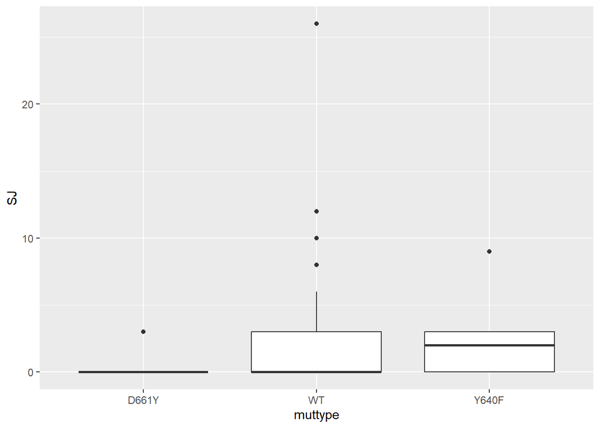

```r
RA3 %>% ggplot(aes(muttype, SJ))+geom_boxplot()
```

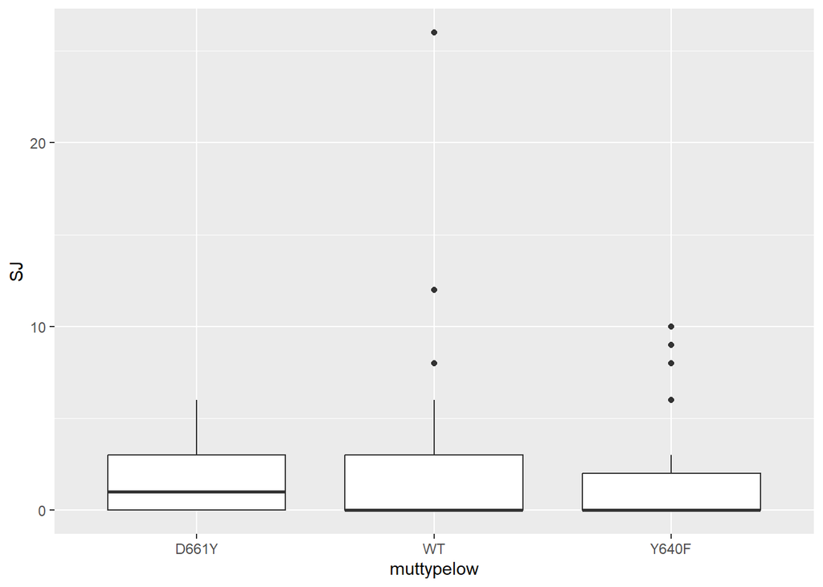

```r
RA4 %>% ggplot(aes(muttypelow, SJ))+geom_boxplot()
```

Lots of zeros, log transform won’t help, run Kruskal-Wallis

```r
RA3 %>% kruskal_test(SJ~muttype)
```

```
## # A tibble: 1 × 6
##   .y.       n statistic    df     p method
## * <chr> <int>     <dbl> <int> <dbl> <chr>
## 1 SJ       96      1.57     2 0.457 Kruskal-Wallis
```

```r
RA4 %>% kruskal_test(SJ~muttypelow)
```

```
## # A tibble: 1 × 6
##   .y.       n statistic    df     p method
## * <chr> <int>     <dbl> <int> <dbl> <chr>
## 1 SJ       84     0.524     2 0.769 Kruskal-Wallis
```

```r
#making a data set
kruskal <-
  RA3 %>% kruskal_test(SJ~muttype)

kruskal008 <-
  RA4 %>% kruskal_test(SJ~muttypelow)
```

### TJ anova

> ran kruskal-wallis, not significant

Make a box plot

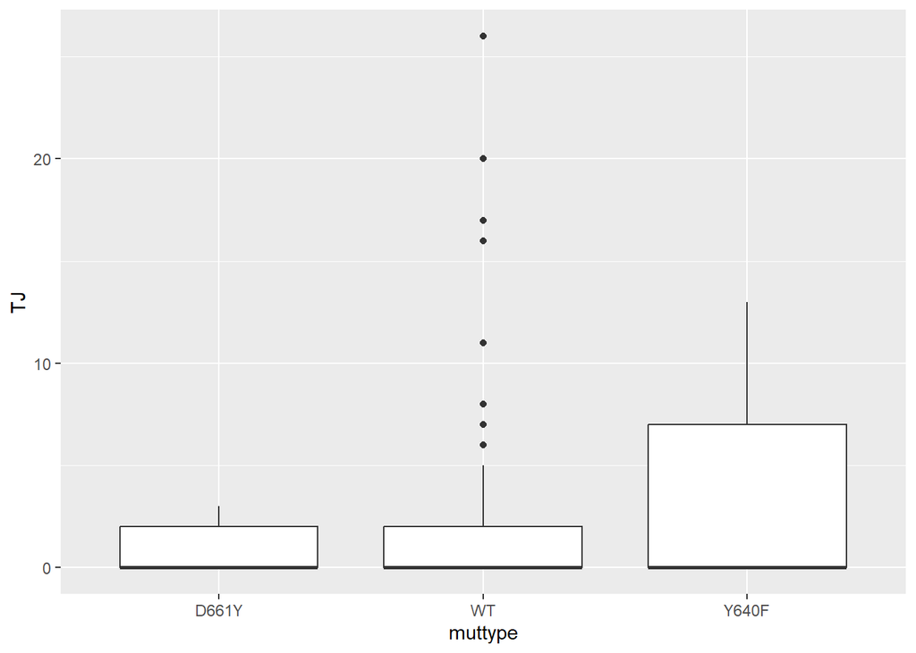

```r
RA3 %>% ggplot(aes(muttype, TJ))+geom_boxplot()
```

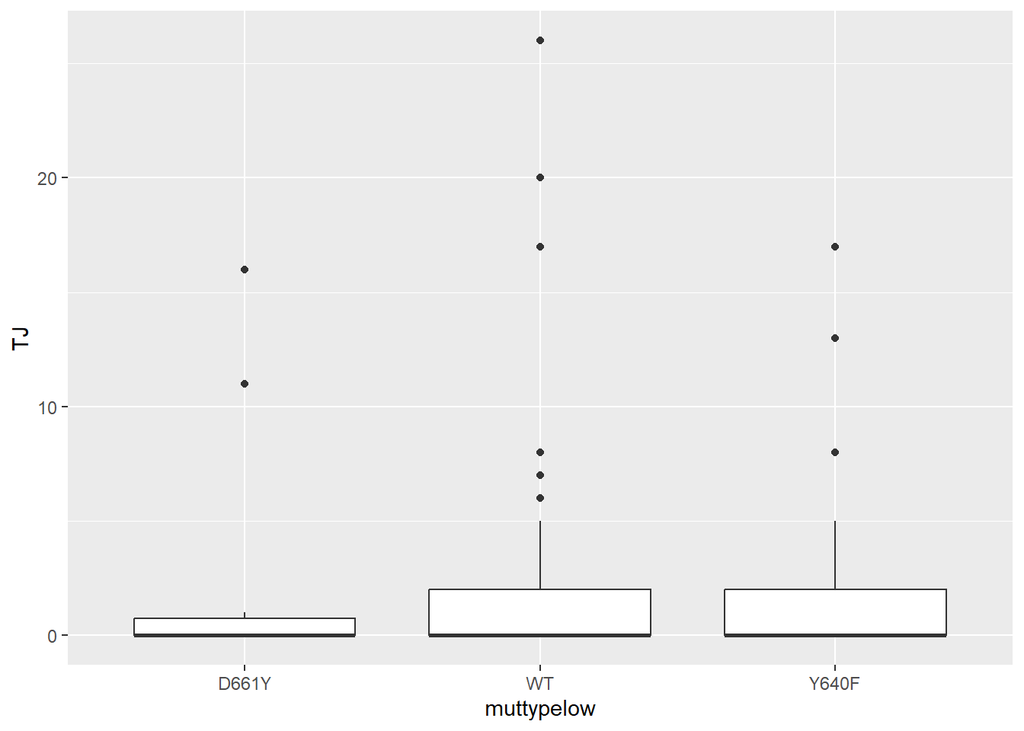

```r
RA4 %>% ggplot(aes(muttypelow, TJ))+geom_boxplot()
```

Lots of zeros, log transform won’t help, run Kruskal-Wallis

```r
RA3 %>% kruskal_test(TJ~muttype)
```

```
## # A tibble: 1 × 6
##   .y.       n statistic    df     p method
## * <chr> <int>     <dbl> <int> <dbl> <chr>
## 1 TJ       96     0.192     2 0.908 Kruskal-Wallis
```

```r
RA4 %>% kruskal_test(TJ~muttypelow)
```

```
## # A tibble: 1 × 6
##   .y.       n statistic    df     p method
## * <chr> <int>     <dbl> <int> <dbl> <chr>
## 1 TJ       84     0.515     2 0.773 Kruskal-Wallis
```

```r
#making a data set
kruskal <-
  RA3 %>% kruskal_test(TJ~muttype) %>%
  rbind(kruskal)

kruskal008 <-
  RA4 %>% kruskal_test(TJ~muttypelow) %>%
  rbind(kruskal008)
```

### pt_global anova

> ran kruskal-wallis, not significant

Make a box plot

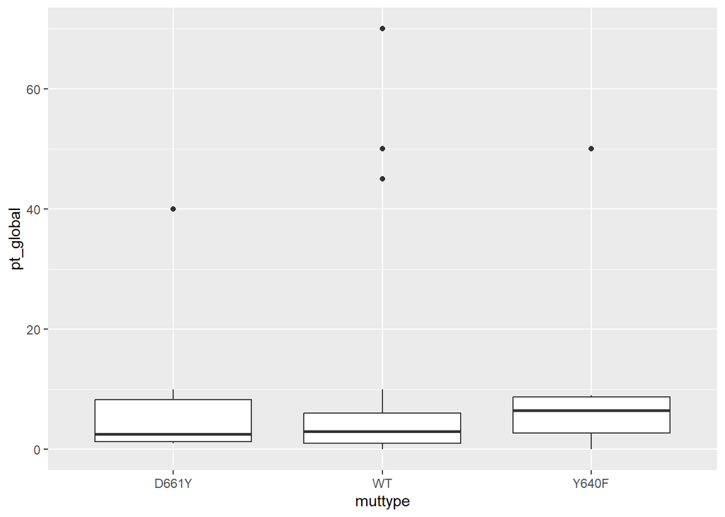

```r
RA3 %>% ggplot(aes(muttype, pt_global))+geom_boxplot()
```

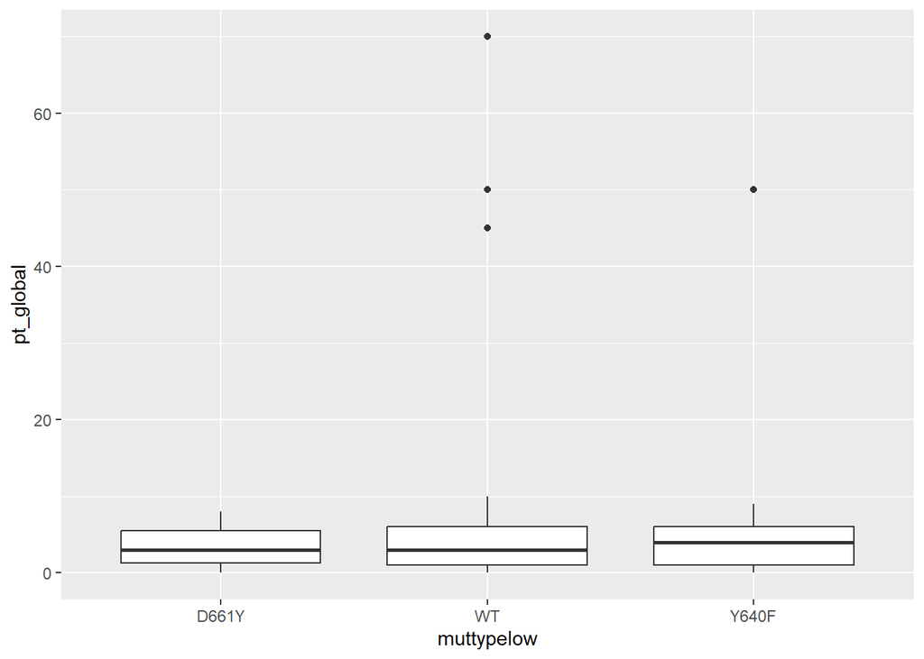

```r
RA4 %>% ggplot(aes(muttypelow, pt_global))+geom_boxplot()
```

Lots of zeros, log transform won’t help, run Kruskal-Wallis

```r
RA3 %>% kruskal_test(pt_global~muttype)
```

```
## # A tibble: 1 × 6
##   .y.           n statistic    df     p method
## * <chr>     <int>     <dbl> <int> <dbl> <chr>
## 1 pt_global    96      1.00     2 0.607 Kruskal-Wallis
```

```r
RA4 %>% kruskal_test(pt_global~muttypelow)
```

```
## # A tibble: 1 × 6
##   .y.           n statistic    df     p method
## * <chr>     <int>     <dbl> <int> <dbl> <chr>
## 1 pt_global    84     0.184     2 0.912 Kruskal-Wallis
```

```r
#making a data set
kruskal <-
  RA3 %>% kruskal_test(pt_global~muttype) %>%
  rbind(kruskal)

kruskal008 <-
  RA4 %>% kruskal_test(pt_global~muttypelow) %>%
  rbind(kruskal008)
```

### pro_global anova

> ran kruskal-wallis, not significant

Make a box plot

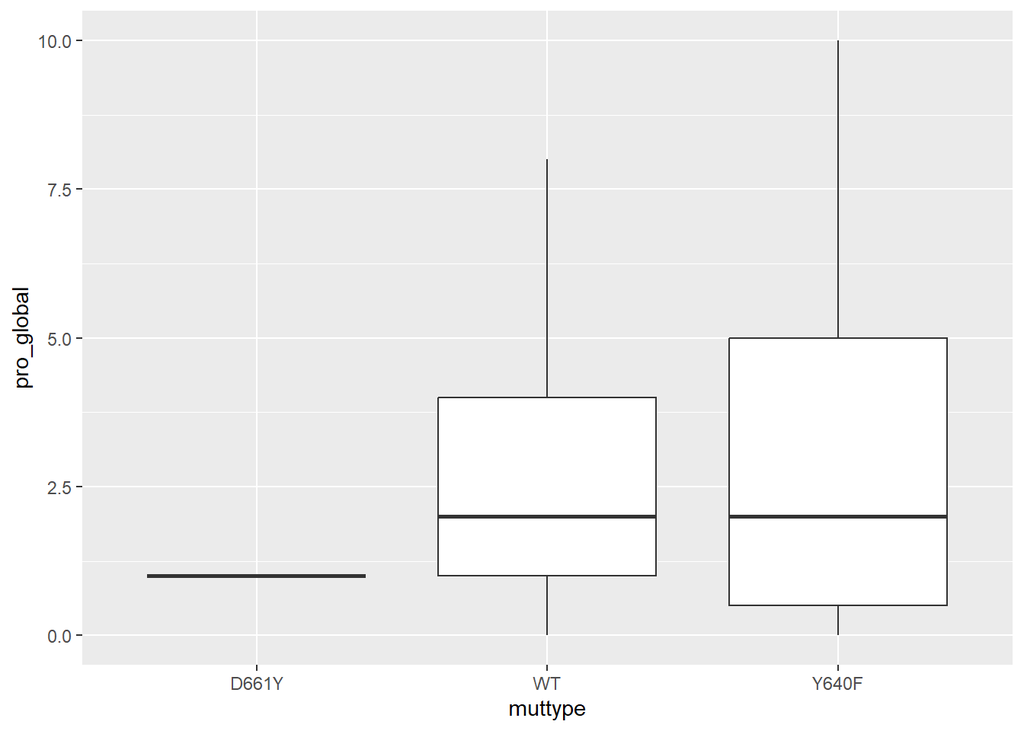

```r
RA3 %>% ggplot(aes(muttype, pro_global))+geom_boxplot()
```

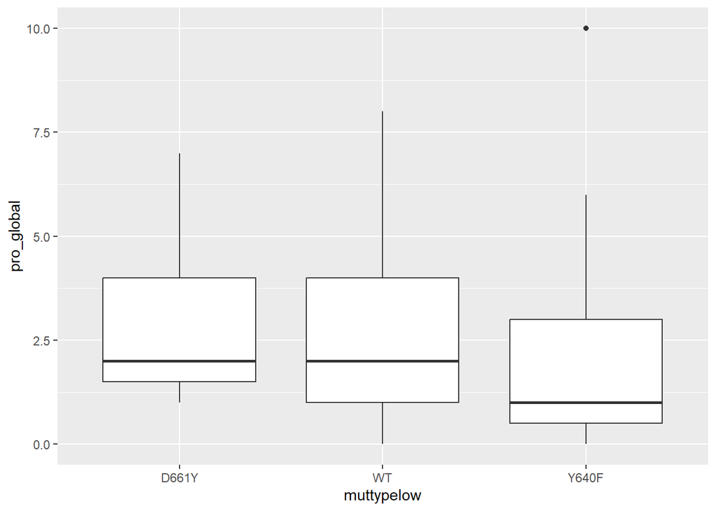

```r
RA4 %>% ggplot(aes(muttypelow, pro_global))+geom_boxplot()
```

Lots of zeros, log transform won’t help, run Kruskal-Wallis

```r
RA3 %>% kruskal_test(pro_global~muttype)
```

```
## # A tibble: 1 × 6
##   .y.            n statistic    df     p method
## * <chr>      <int>     <dbl> <int> <dbl> <chr>
## 1 pro_global    96      1.80     2 0.407 Kruskal-Wallis
```

```r
RA4 %>% kruskal_test(pro_global~muttypelow)
```

```
## # A tibble: 1 × 6
##   .y.            n statistic    df     p method
## * <chr>      <int>     <dbl> <int> <dbl> <chr>
## 1 pro_global    84      1.98     2 0.371 Kruskal-Wallis
```

```r
#making a data set
kruskal <-
  RA3 %>% kruskal_test(pro_global~muttype) %>%
  rbind(kruskal)

kruskal008 <-
  RA4 %>% kruskal_test(pro_global~muttypelow) %>%
  rbind(kruskal008)
```

### hopCCP anova

> no sig with welch’s and also testing mutations alone

Make a box plot

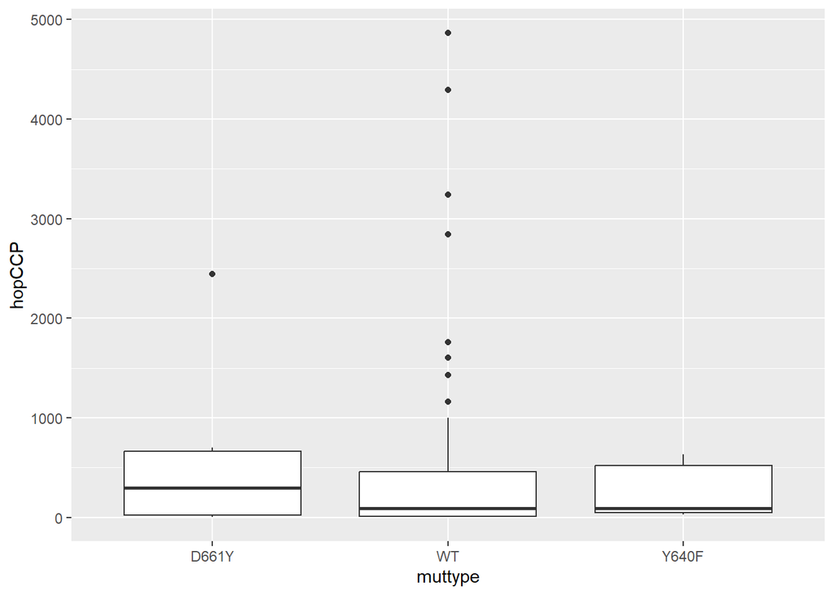

```r
RA3 %>% ggplot(aes(muttype, hopCCP))+geom_boxplot()
```

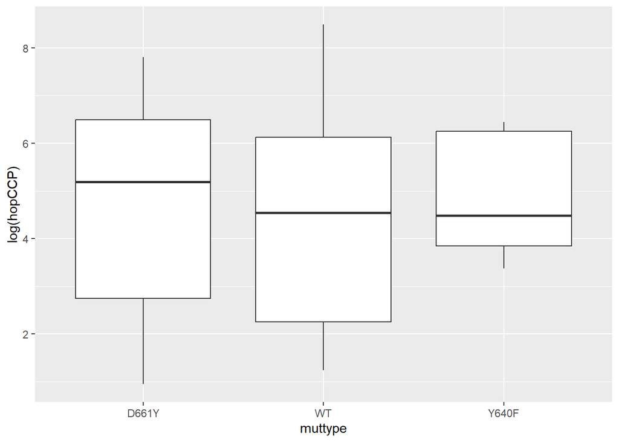

```r
# try log transform. there are no zeros
RA3 %>% ggplot(aes(muttype, log(hopCCP)))+geom_boxplot()
```

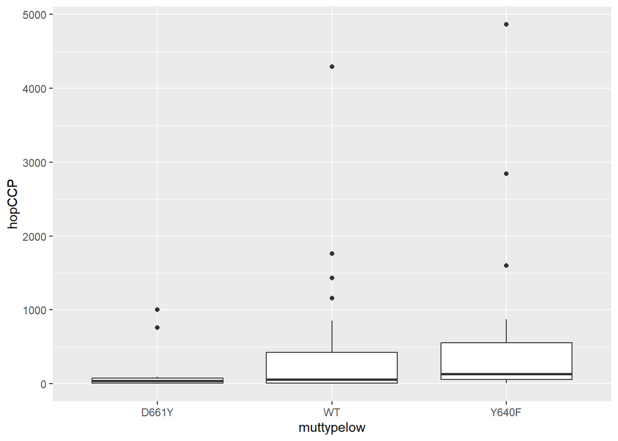

```r
RA4 %>% ggplot(aes(muttypelow, hopCCP))+geom_boxplot()
```

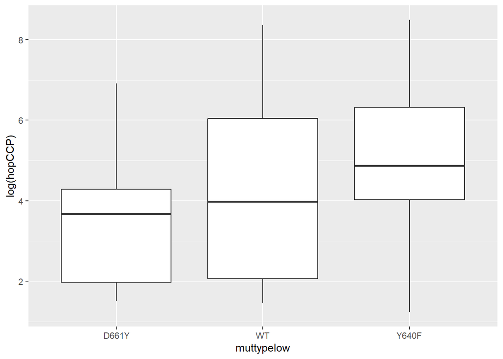

```r
# try log transform. there are no zeros
RA4 %>% ggplot(aes(muttypelow, log(hopCCP)))+geom_boxplot()
```

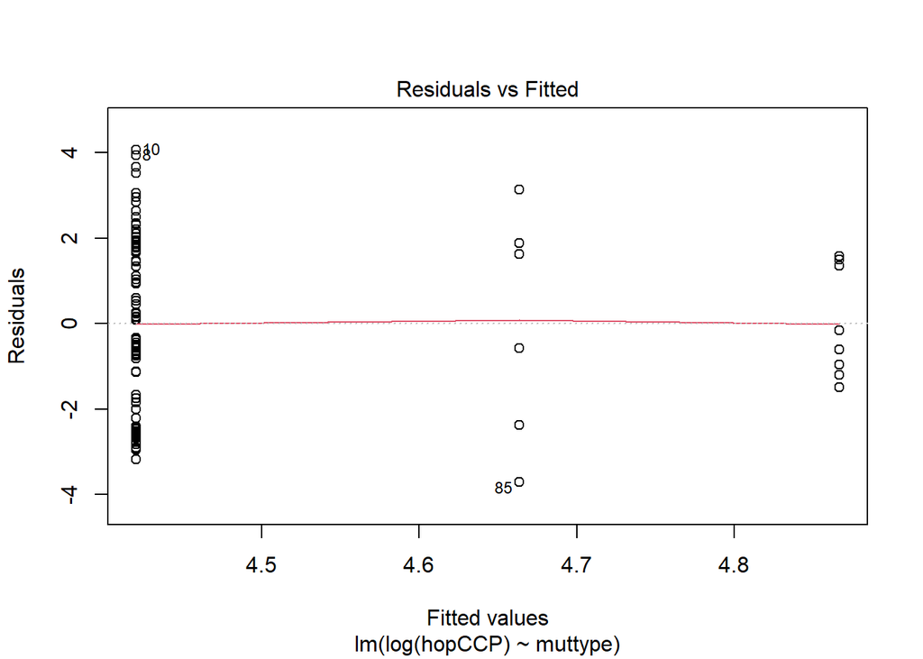

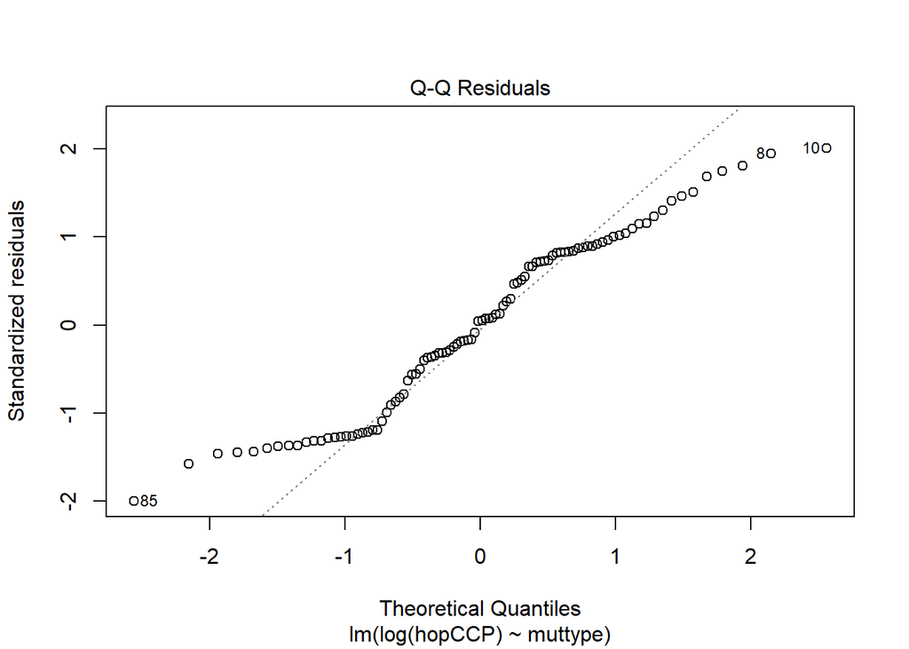

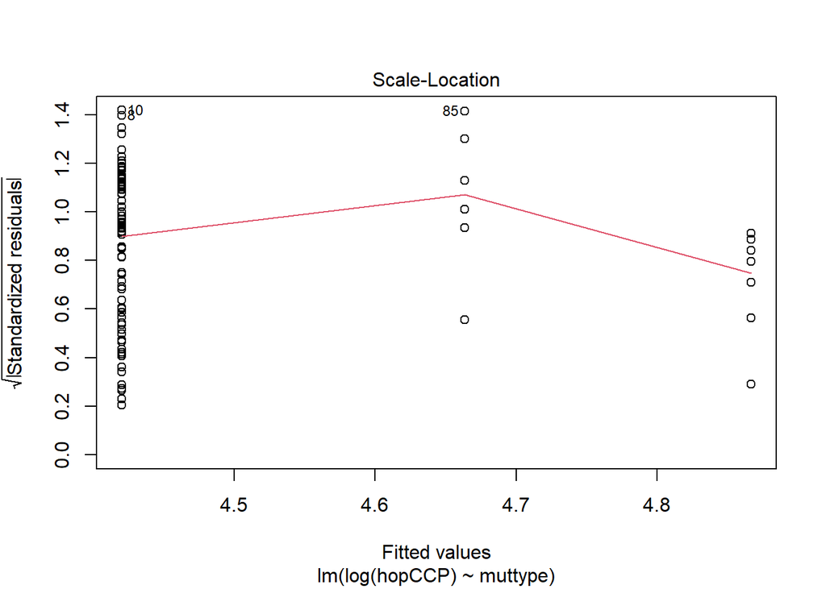

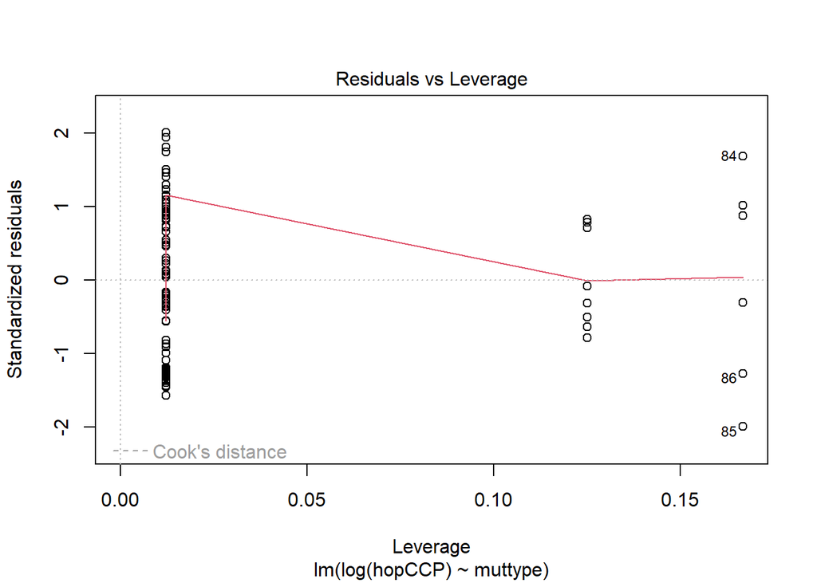

```r
mod<- lm(log(hopCCP)~muttype, data = RA3)
plot(mod)
```

nonequal variance, so welch’s anova

```r
RA3 %>% welch_anova_test(log(hopCCP)~muttype)
```

```
## # A tibble: 1 × 7
##   .y.             n statistic   DFn   DFd     p method
## * <chr>       <int>     <dbl> <dbl> <dbl> <dbl> <chr>
## 1 log(hopCCP)    96      0.37     2  9.49   0.7 Welch ANOVA
```

```r
RA4 %>% welch_anova_test(log(hopCCP)~muttypelow)
```

```
## # A tibble: 1 × 7
##   .y.             n statistic   DFn   DFd     p method
## * <chr>       <int>     <dbl> <dbl> <dbl> <dbl> <chr>
## 1 log(hopCCP)    84       1.9     2  27.9 0.169 Welch ANOVA
```

```r
#making a dataset

welch <-
  RA3 %>% welch_anova_test(log(hopCCP)~muttype) %>%
  rbind(welch)

welch008 <-
  RA4 %>% welch_anova_test(log(hopCCP)~muttypelow) %>%
  rbind(welch008)

# appending to hypothetical csv

#RA3 %>% welch_anova_test(log(hopCCP)~muttype)%>%
#  write_csv(file = "welch.csv", append = TRUE)

#RA4 %>% welch_anova_test(log(hopCCP)~muttypelow)%>%
#  write_csv(file = "welch.csv", append = TRUE)
```

trying welch’s t test on mut instead of muttype after seeing difference in box plot

```r
t.test(log(hopCCP)~muts, data = RA3)
```

```
##
##  Welch Two Sample t-test
##
## data:  log(hopCCP) by muts
## t = -0.17152, df = 6.7326, p-value = 0.8689
## alternative hypothesis: true difference in means between group D661Y and group Y640F is not equal to 0
## 95 percent confidence interval:
##  -3.024030  2.618078
## sample estimates:
## mean in group D661Y mean in group Y640F
##            4.663559            4.866535
```

```r
t.test(log(hopCCP)~muts008, data = RA4)
```

```
##
##  Welch Two Sample t-test
##
## data:  log(hopCCP) by muts008
## t = -1.8931, df = 19.298, p-value = 0.07343
## alternative hypothesis: true difference in means between group D661Y and group Y640F is not equal to 0
## 95 percent confidence interval:
##  -2.727302  0.135338
## sample estimates:
## mean in group D661Y mean in group Y640F
##            3.575853            4.871835
```

### CCP anova

> ran kruskal-wallis because really bad normality, not significant

using medians filled in ccp values Make a box plot

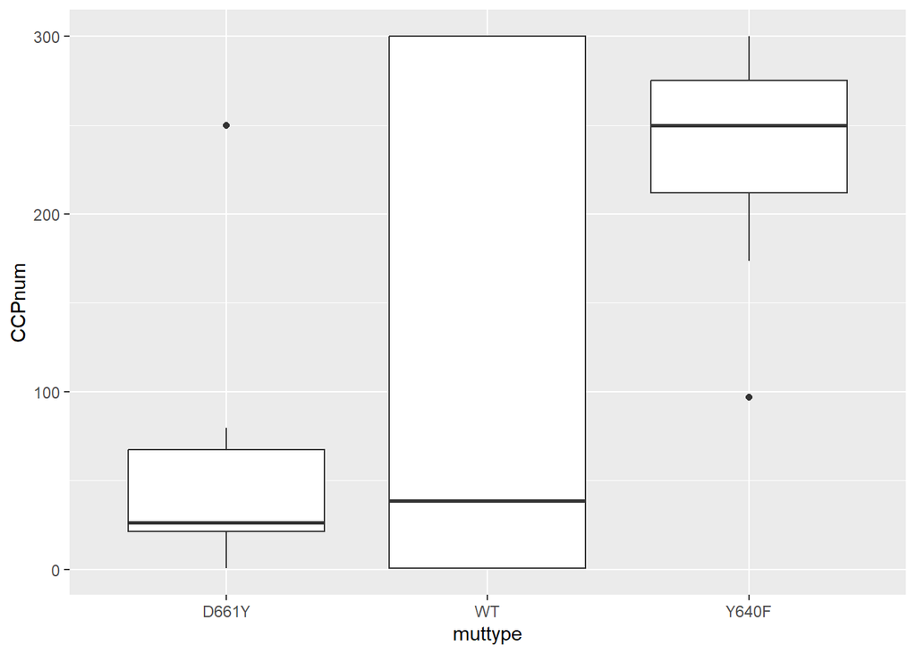

```r
RA3 %>% ggplot(aes(muttype, CCPnum))+geom_boxplot()
```

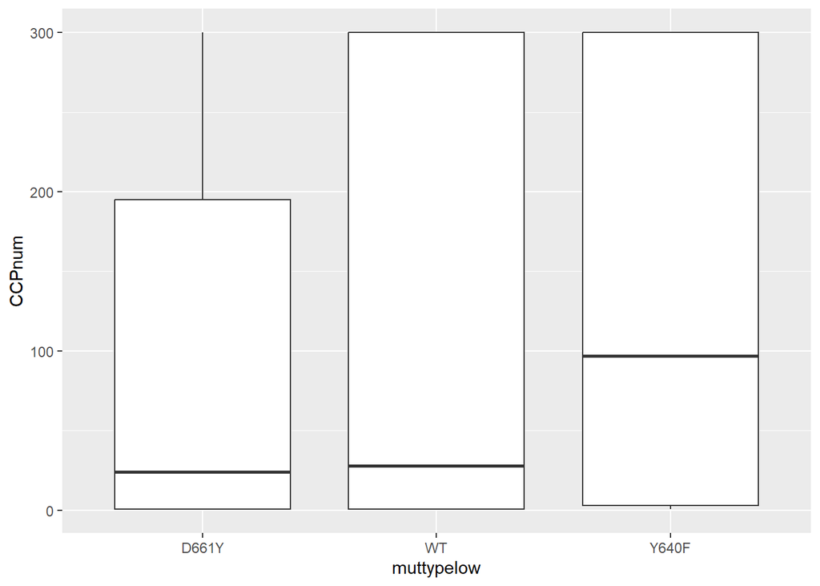

```r
RA4 %>% ggplot(aes(muttypelow, CCPnum))+geom_boxplot()
```